# MScA, Bayesian Methods (32014) Week 7 Workshop, Part 1

Y. Balasanov, M.Tselishchev, © iLykei 2016

# 1 References

[G] Andrew Gelman, John B. Carlin, Hal S. Stern, David B. Dunson, Aki Vehtari, Donald B. Rubin, Bayesian Data Analysis, Third Edition, 2013, Taylor & Francis Group.  
[K] John K. Kruschke, Doing Bayesian Data Analysis, A Tutorial with R, JAGS, and STAN, 2015, Elsevier.

# 2 Two group analysis: Fitting normal model for 2 groups with no predictors

## 2.1 IQ data

This example is based on [K], Chapter 16.

One example of two-groups problem is testing effect of a drug when one group receives a placebo and another receives the drug. The response variable is result of IQ test.

Prepare the data.

```r
myDataFrame = read.csv( file=paste(dataPath,"TwoGroupIQ.csv",sep="/") )
y = as.numeric(myDataFrame[,"Score"])
x = as.numeric(as.factor(myDataFrame[,"Group"]))
(xLevels = levels(as.factor(myDataFrame[,"Group"])))
```

```
## [1] "Placebo"    "Smart Drug"
```

```r
Ntotal = length(y)
# Specify the data in a list, for later shipment to JAGS:
dataList = list(
    y = y ,
    x = x ,
    Ntotal = Ntotal ,
    meanY = mean(y) ,
    sdY = sd(y)
)
dataList
```

```
## $y
##   [1] 102 107  92 101 110  68 119 106  99 103  90  93  79  89 137 119 126
##  [18] 110  71 114 100  95  91  99  97 106 106 129 115 124 137  73  69  95
##  [35] 102 116 111 134 102 110 139 112 122  84 129 112 127 106 113 109 208
##  [52] 114 107  50 169 133  50  97 139  72 100 144 112 109  98 106 101 100
##  [69] 111 117 104 106  89  84  88  94  78 108 102  95  99  90 116  97 107
##  [86] 102  91  94  95  86 108 115 108  88 102 102 120 112 100 105 105  88
## [103]  82 111  96  92 109  91  92 123  61  59 105 184  82 138  99  93  93
## [120]  72
##
## $x
##   [1] 2 2 2 2 2 2 2 2 2 2 2 2 2 2 2 2 2 2 2 2 2 2 2 2 2 2 2 2 2 2 2 2 2 2 2
##  [36] 2 2 2 2 2 2 2 2 2 2 2 2 2 2 2 2 2 2 2 2 2 2 2 2 2 2 2 2 1 1 1 1 1 1 1
##  [71] 1 1 1 1 1 1 1 1 1 1 1 1 1 1 1 1 1 1 1 1 1 1 1 1 1 1 1 1 1 1 1 1 1 1 1
## [106] 1 1 1 1 1 1 1 1 1 1 1 1 1 1 1
##
## $Ntotal
## [1] 120
##
## $meanY
## [1] 104.1333
##
## $sdY
## [1] 22.43532
```

The utilities file from [K].

```r
suppressWarnings(source(paste(dataPath,"DBDA2E-utilities.R",sep="/")))
```

```
##
## Kruschke, J. K. (2015). Doing Bayesian Data Analysis, Second Edition:
## A Tutorial with R, JAGS, and Stan. Academic Press / Elsevier.
```

```r
suppressWarnings(library(rstan))
```

## 2.2 Normal assumption

Assuming that both groups samples have normal distributions, estimate the parameters and compare them.

Write description of the model for stan.

(Do it yourself)

```r
# Use the description for Stan from file "ch16_2.stan"
modelString = "
data {
    int<lower=1> Ntotal;
    int x[Ntotal];
    real y[Ntotal];
    real meanY;
    real sdY;
}
transformed data {
    real unifLo;
    real unifHi;
    real normalSigma;
    unifLo = sdY/1000;
    unifHi = sdY*1000;
    normalSigma = sdY*100;
}
parameters {
    real mu[2];
    real<lower=0> sigma[2];
}
model {
    sigma ~ uniform(unifLo, unifHi);
    mu ~ normal(meanY, normalSigma);
    for ( i in 1:Ntotal ) {
        y[i] ~ normal(mu[x[i]] , sigma[x[i]]);
    }
}
"
```

If running the description in `modelString` for the first time create `stanDSONormal`, otherwise reuse it.

```r
stanDsoNormal<-stan_model( model_code=modelString )
save(stanDsoNormal,file=paste(dataPath,"DSONormal1.Rds",sep="/"))
```

If saved DSO is used load it, then run the chains.

```r
load(file=paste(dataPath,"DSONormal1.Rds",sep="/"))
```

Run MCMC.

```r
parameters = c( "mu" , "sigma")     # The parameters to be monitored
adaptSteps = 500               # Number of steps to "tune" the samplers
burnInSteps = 1000
nChains = 4
thinSteps = 1
numSavedSteps<-5000
stanFitNormal<-sampling(stanDsoNormal,
                   data = dataList ,
                   pars = parameters , # optional
                   chains = nChains ,
                   iter = ( ceiling(numSavedSteps/nChains)*thinSteps+burnInSteps ) ,
                   warmup = burnInSteps ,
                   init = "random" , # optional
                   thin = thinSteps
              )
```

[output not shown]

[output cut: 40 more lines]

[output not shown]

Save the fit object for further analysis.

```r
save(stanFitNormal,file=paste(dataPath,"StanNormalFit2Groups.Rdata",sep="/"))
load(paste(dataPath,"StanNormalFit2Groups.Rdata",sep="/"))
```

Explore the results.

```r
# text statistics:
print (stanFitNormal)
```

```
## Inference for Stan model: 83ad30419bf76c40613a3610f5b806c0.
## 4 chains, each with iter=2250; warmup=1000; thin=1;
## post-warmup draws per chain=1250, total post-warmup draws=5000.
##
##             mean se_mean   sd    2.5%     25%     50%     75%   97.5%
## mu[1]     100.03    0.04 2.49   95.33   98.32  100.02  101.72  104.85
## mu[2]     107.79    0.05 3.27  101.28  105.60  107.85  109.99  114.13
## sigma[1]   18.32    0.03 1.79   15.24   17.07   18.17   19.40   22.32
## sigma[2]   25.99    0.03 2.32   22.00   24.36   25.80   27.46   30.99
## lp__     -423.21    0.03 1.42 -426.64 -423.98 -422.88 -422.16 -421.45
##          n_eff Rhat
## mu[1]     5000    1
## mu[2]     4169    1
## sigma[1]  5000    1
## sigma[2]  4589    1
## lp__      2292    1
##
## Samples were drawn using NUTS(diag_e) at Wed Nov 08 11:48:30 2017.
## For each parameter, n_eff is a crude measure of effective sample size,
## and Rhat is the potential scale reduction factor on split chains (at
## convergence, Rhat=1).
```

```
## ci_level: 0.8 (80% intervals)
```

```
## outer_level: 0.95 (95% intervals)
```

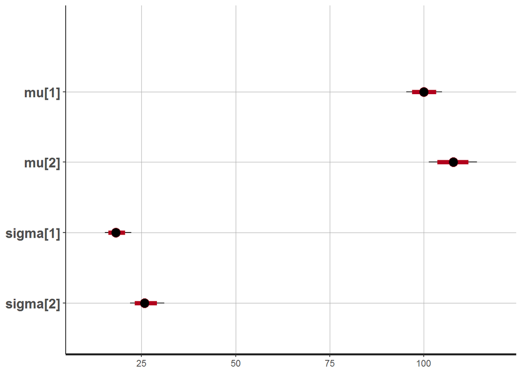

```r
# estimates & hdi:
plot(stanFitNormal)
```

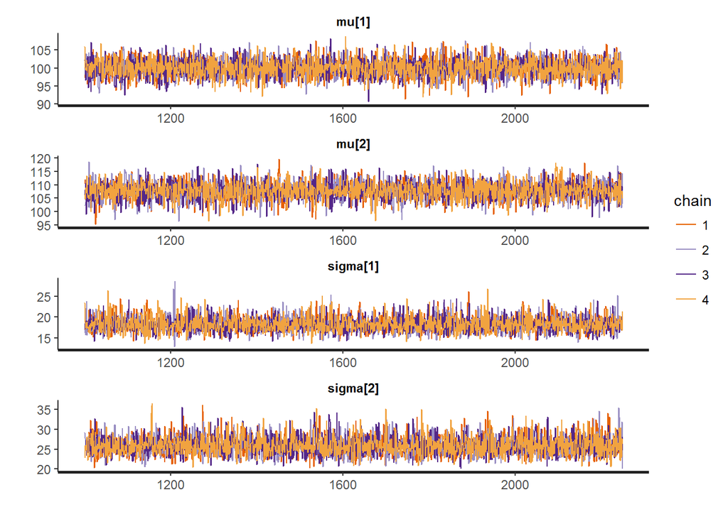

```r
# samples
rstan::traceplot(stanFitNormal, ncol=1, inc_warmup=F)
```

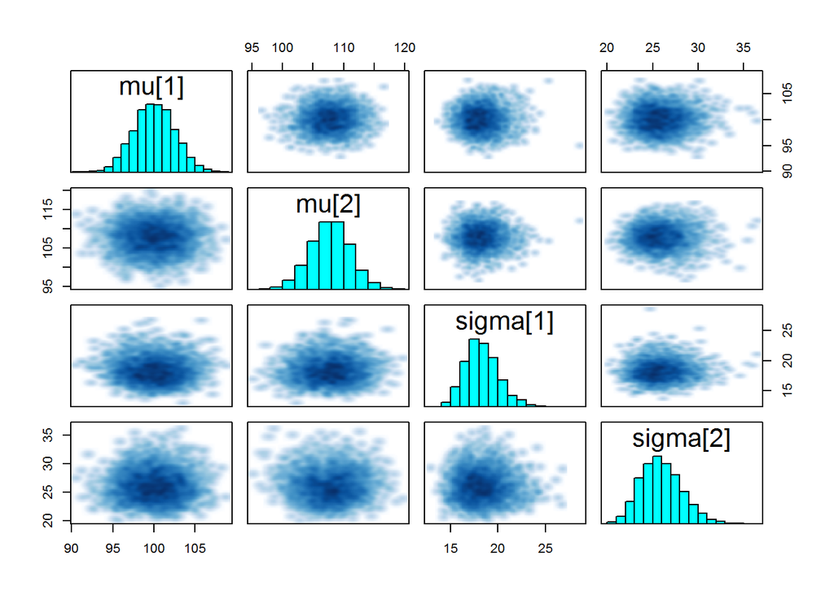

```r
pairs(stanFitNormal, pars=c('mu','sigma'))
```

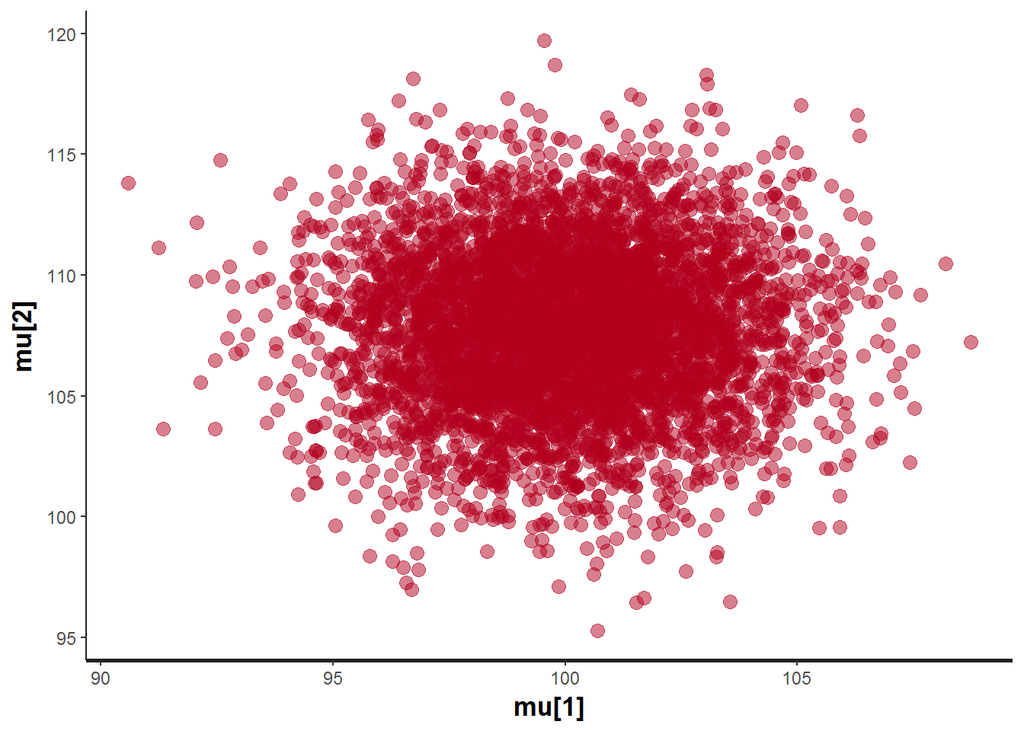

```r
stan_scat(stanFitNormal, c('mu[1]','mu[2]'))
```

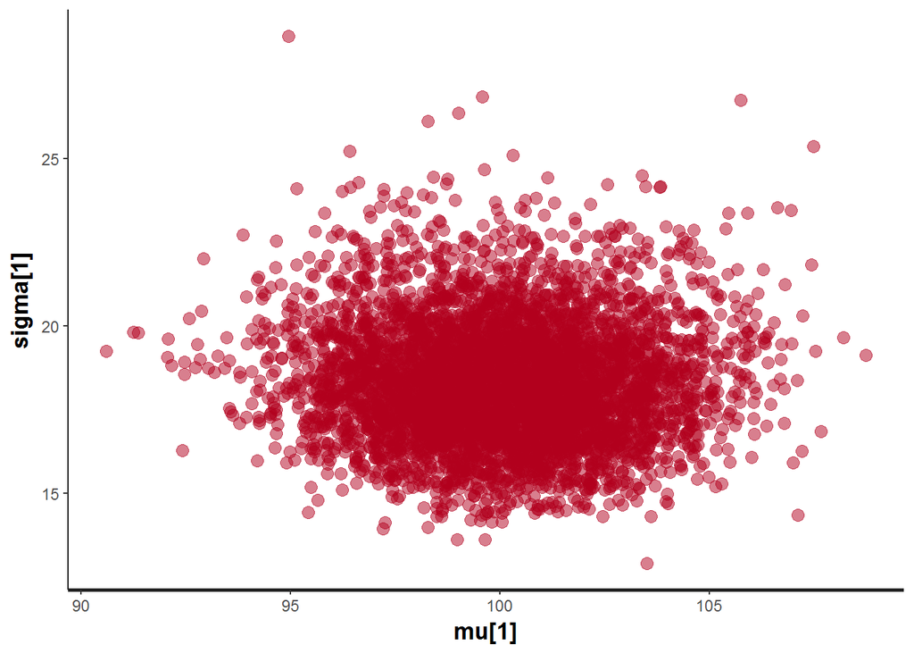

```r
stan_scat(stanFitNormal, c('mu[1]','sigma[1]'))
```

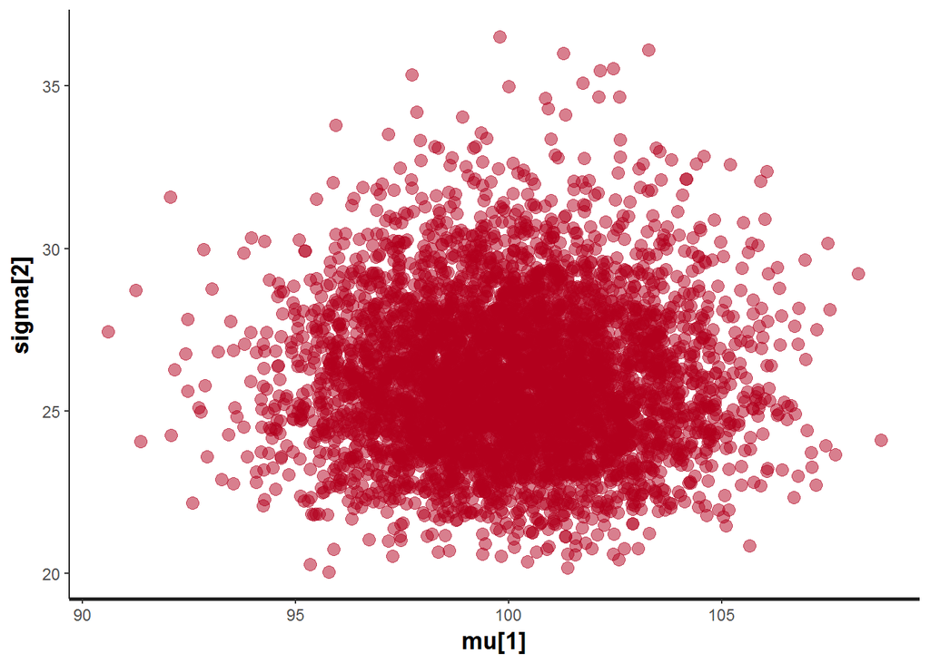

```r
stan_scat(stanFitNormal, c('mu[1]','sigma[2]'))
```

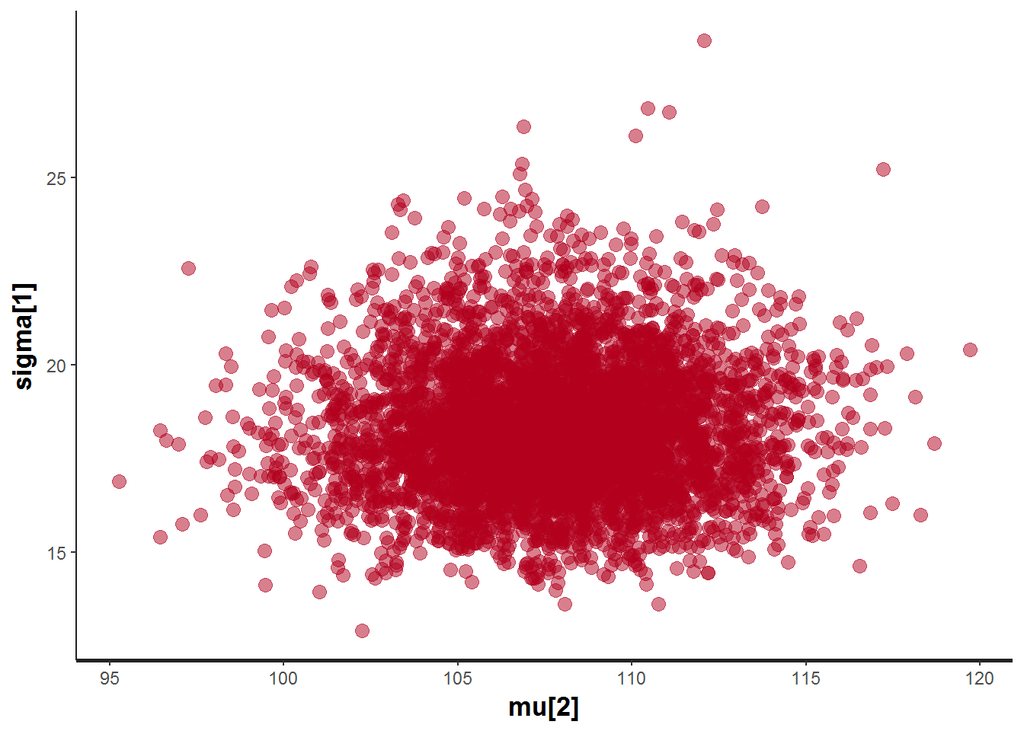

```r
stan_scat(stanFitNormal, c('mu[2]','sigma[1]'))
```

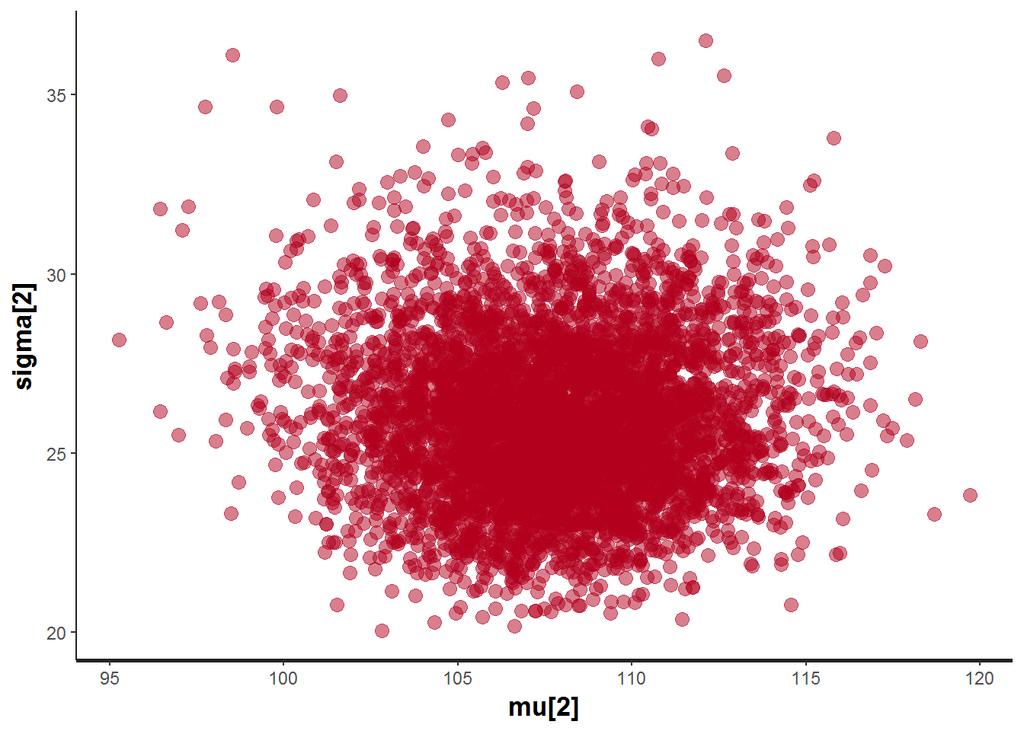

```r
stan_scat(stanFitNormal, c('mu[2]','sigma[2]'))
```

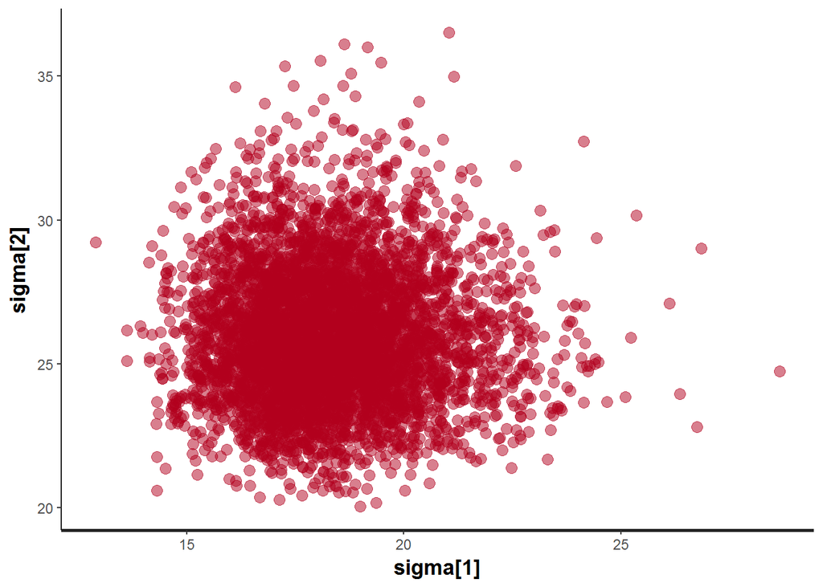

```r
stan_scat(stanFitNormal, c('sigma[1]','sigma[2]'))
```

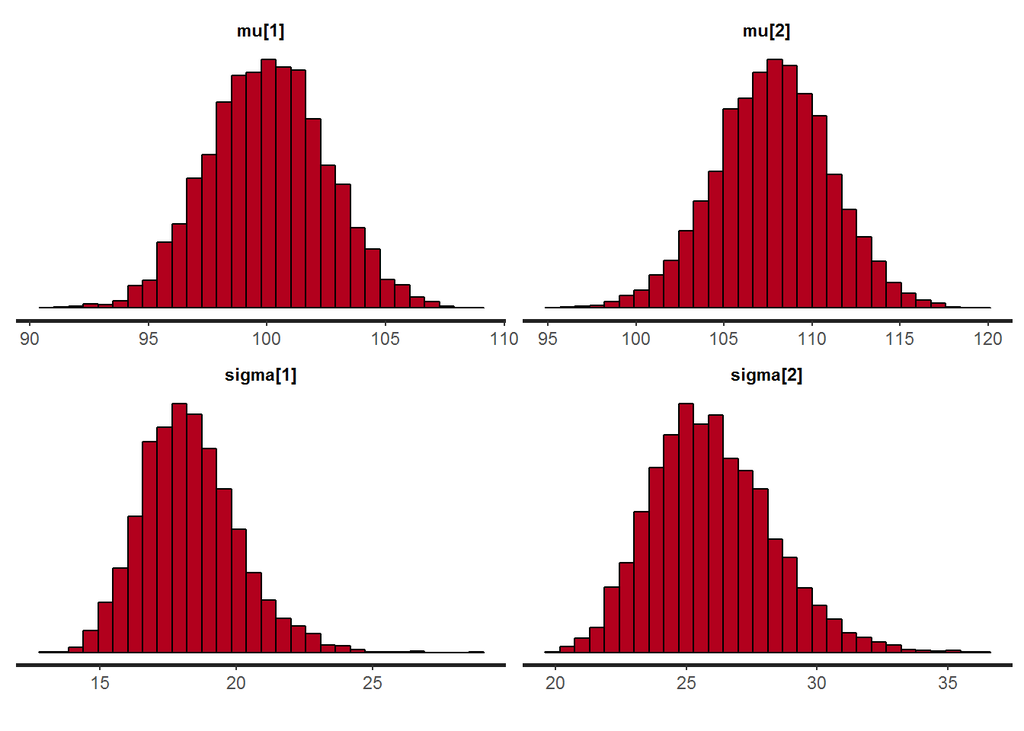

```r
stan_hist(stanFitNormal)
```

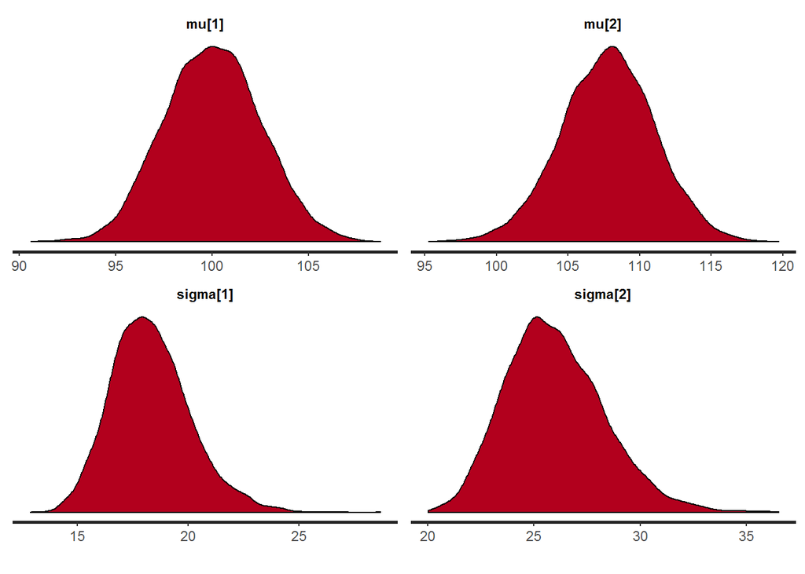

```r
stan_dens(stanFitNormal)
```

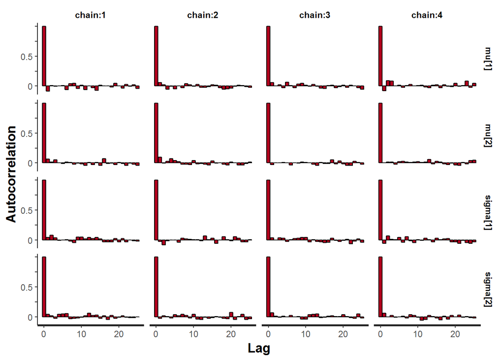

```r
# autocorrelation:
stan_ac(stanFitNormal, separate_chains = T)
```

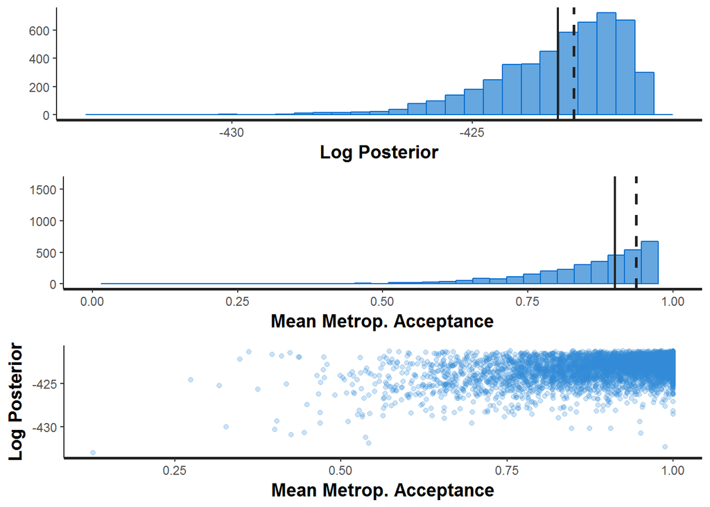

```r
stan_diag(stanFitNormal,information = "sample",chain=0)
```

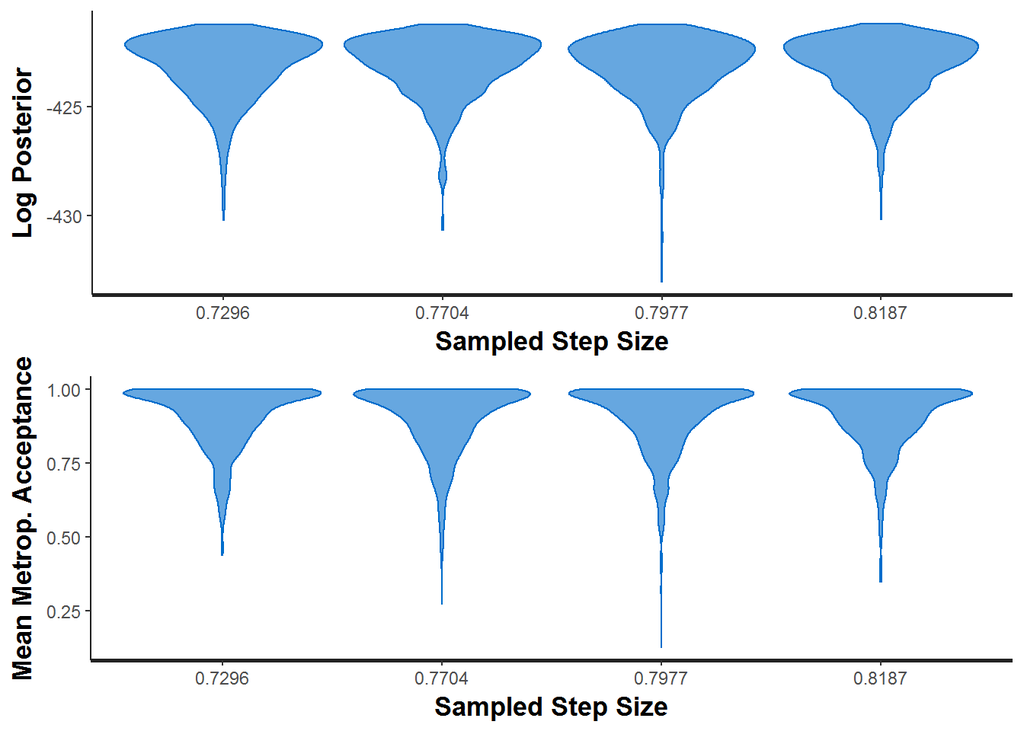

```r
stan_diag(stanFitNormal,information = "stepsize",chain = 0)
```

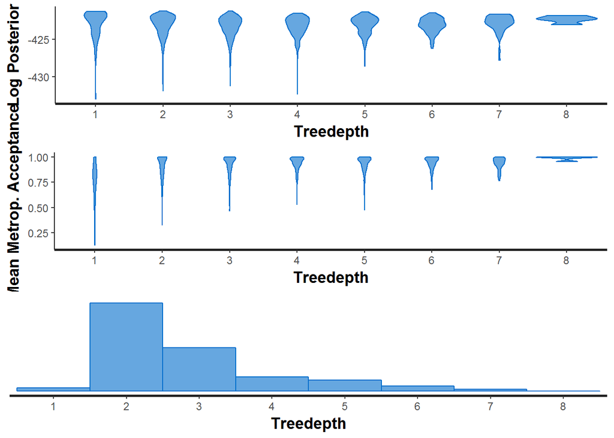

```r
stan_diag(stanFitNormal,information = "treedepth",chain = 0)
```

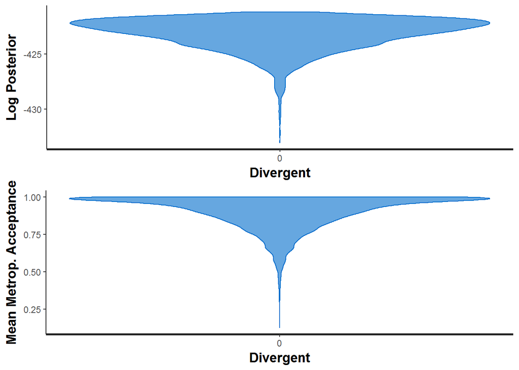

```r
stan_diag(stanFitNormal,information = "divergence",chain = 0)
```

If you prefer output using coda class reformat the chains into coda:

```r
stan2coda <- function(stanFitNormal) {
    # apply to all chains
    mcmc.list(lapply(1:ncol(stanFitNormal), function(x) mcmc(as.array(stanFitNormal)[,x,])))
}
codaSamples <- stan2coda(stanFitNormal)
summary(codaSamples)
```

```
##
## Iterations = 1:1250
## Thinning interval = 1
## Number of chains = 4
## Sample size per chain = 1250
##
## 1. Empirical mean and standard deviation for each variable,
##    plus standard error of the mean:
##
##             Mean    SD Naive SE Time-series SE
## mu[1]     100.03 2.492  0.03525        0.03697
## mu[2]     107.79 3.269  0.04623        0.04965
## sigma[1]   18.32 1.786  0.02526        0.02544
## sigma[2]   25.99 2.321  0.03282        0.03432
## lp__     -423.21 1.420  0.02008        0.02790
##
## 2. Quantiles for each variable:
##
##             2.5%     25%     50%     75%   97.5%
## mu[1]      95.33   98.32  100.02  101.72  104.85
## mu[2]     101.28  105.60  107.85  109.99  114.13
## sigma[1]   15.24   17.07   18.17   19.40   22.32
## sigma[2]   22.00   24.36   25.80   27.46   30.99
## lp__     -426.64 -423.98 -422.88 -422.16 -421.45
```

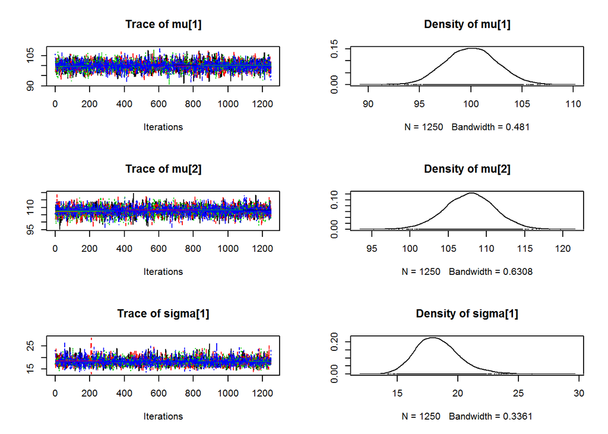

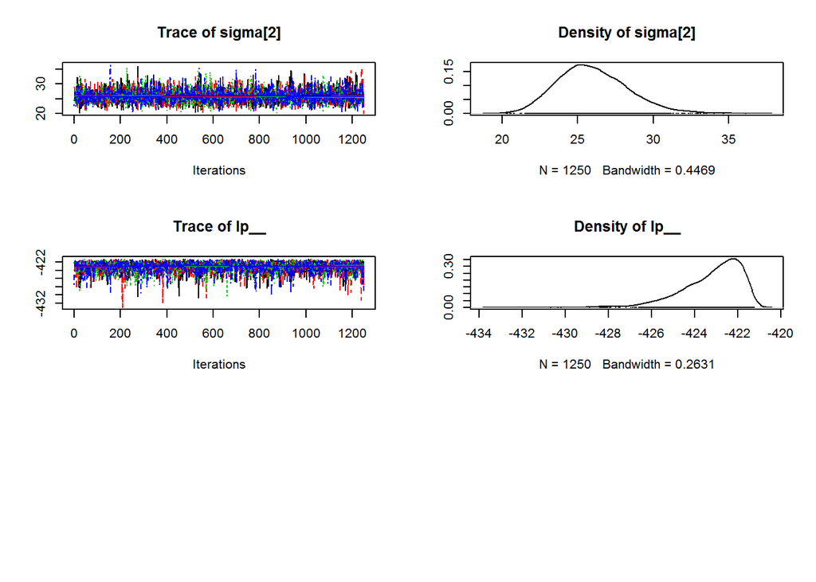

```r
plot(codaSamples)
```

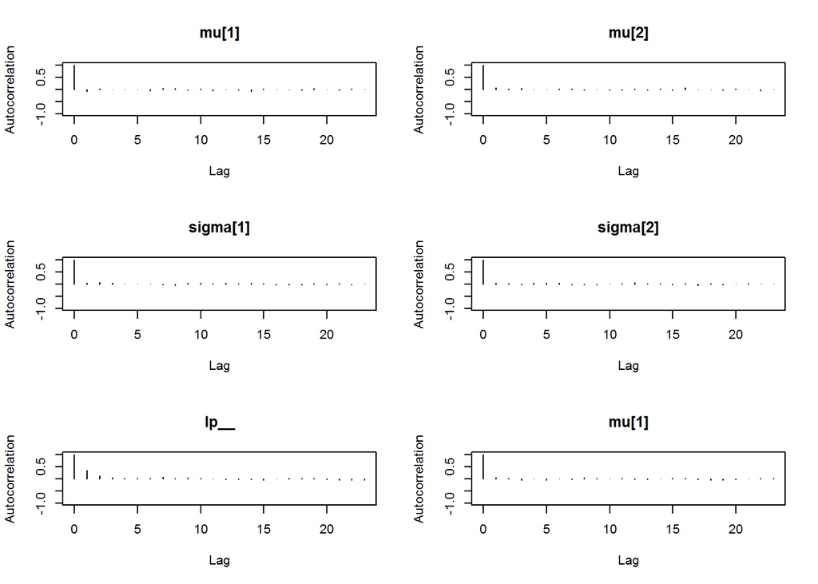

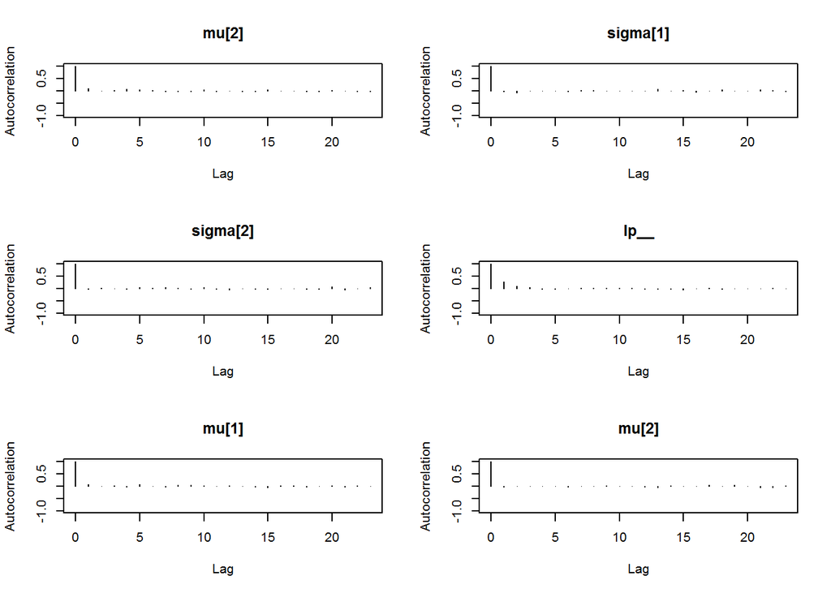

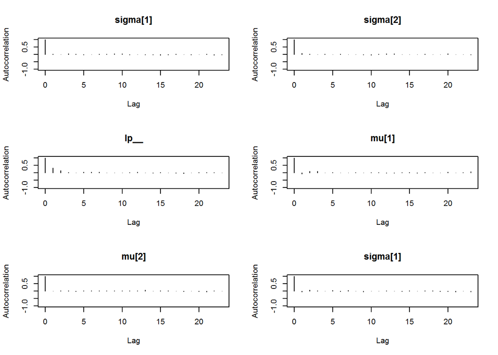

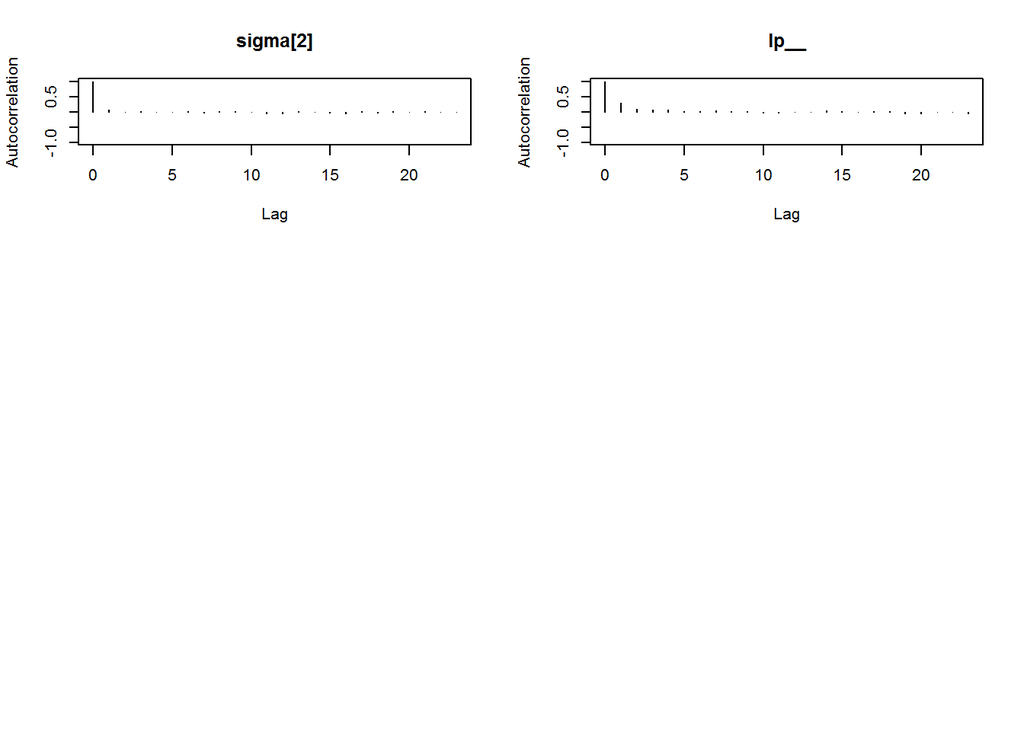

```r
autocorr.plot(codaSamples)
```

```r
effectiveSize(codaSamples)
```

```
##    mu[1]    mu[2] sigma[1] sigma[2]     lp__
## 4672.837 4462.161 5038.361 4591.414 2595.814
```

```r
gelman.diag(codaSamples)
```

```
## Potential scale reduction factors:
##
##          Point est. Upper C.I.
## mu[1]             1       1.00
## mu[2]             1       1.00
## sigma[1]          1       1.00
## sigma[2]          1       1.00
## lp__              1       1.01
##
## Multivariate psrf
##
## 1
```

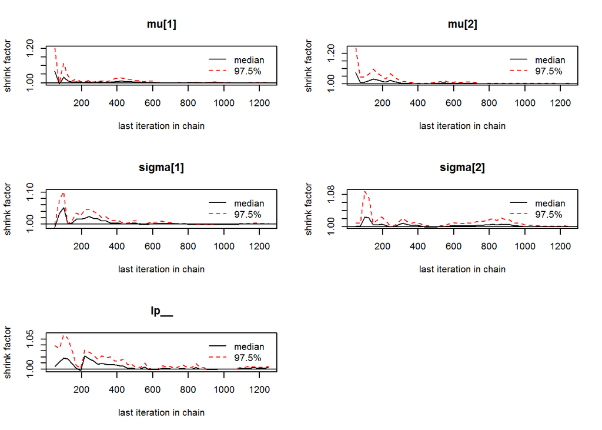

```r
gelman.plot(codaSamples)
```

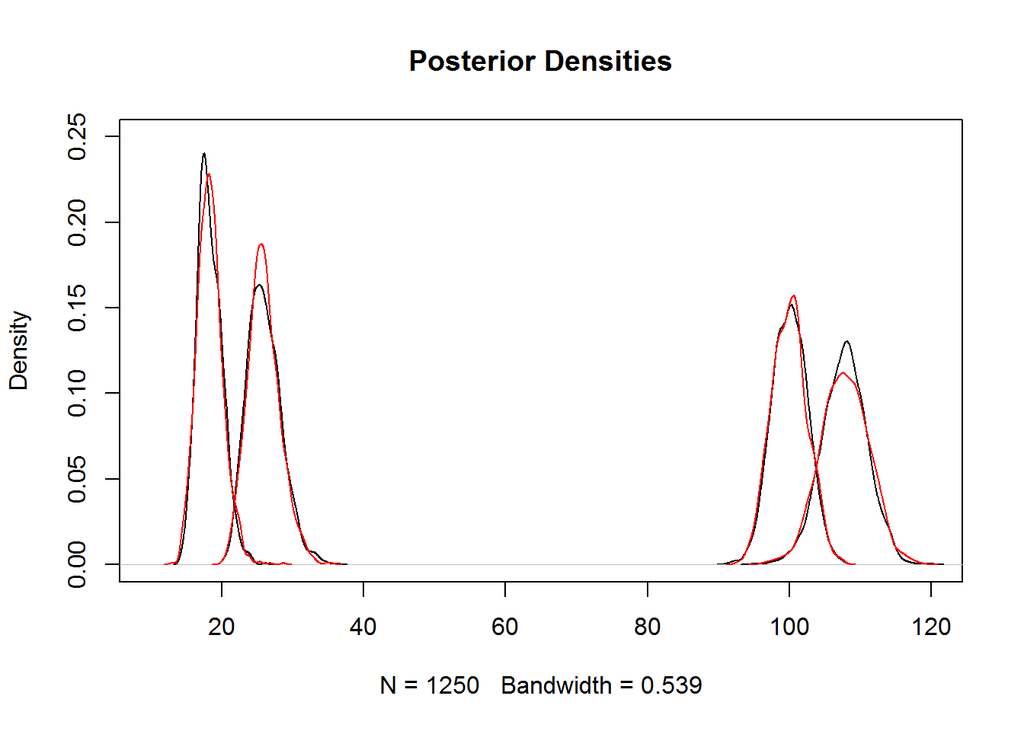

```r
plot(density(codaSamples[[1]][,1]),xlim=c(10,120),ylim=c(0,.25),main="Posterior Densities")  # mu[1], 1st chain
lines(density(codaSamples[[1]][,2]))                         # mu[2], 1st chain
lines(density(codaSamples[[1]][,3]))                         # sigma[1], 1st chain
lines(density(codaSamples[[1]][,4]))                         # sigma[2], 1st chain
lines(density(codaSamples[[2]][,1]),col="red")               # mu[1], 2nd chain
lines(density(codaSamples[[2]][,2]),col="red")               # mu[2], 2nd chain
lines(density(codaSamples[[2]][,3]),col="red")               # sigma[1], 2nd chain
lines(density(codaSamples[[2]][,4]),col="red")               # sigma[2], 2nd chain
```

Or you can use `shinystan` to analyze fitted model

```r
suppressWarnings(library(shinystan))
```

Launch shiny application with the loaded object.

```r
launch_shinystan(stanFitNormal)
```

## 2.3 Robust assumption

Use the robust assumption of Student-t distribution instead of normal.

(Skipped Code)

If running the description in `modelString` for the first time create `stanDSO`, otherwise reuse it.

```r
stanDsoRobust <- stan_model( model_code=modelString )
save(stanDsoRobust,file=paste(dataPath,"DSORobust1.Rds",sep="/"))
```

If saved DSO is used load it, then run the chains.

```r
load(file=paste(dataPath,"DSORobust1.Rds",sep="/"))
```

If necessary, initialize chains.  
Parameter `init` can be: one of digit 0, string “0” or “random”, a function that returns a list, or a list of initial parameter values with which to indicate how the initial values of parameters are specified.

- “0”: initialize all to be zero on the unconstrained support;
- “random”: randomly generated;
- list: a list of lists equal in length to the number of chains (parameter chains), where each list in the list of lists * specifies the initial values of parameters by name for the corresponding chain.
- function: a function that returns a list for specifying the initial values of parameters for a chain. The function can take an optional parameter chain_id.

Since Stan has pretty complicated parameter tuning process during which among other parameters it selects initial values, it may be a good idea to let Stan select default initial parameters until you get enough experience.

Run MCMC.

```r
parameters = c( "mu" , "sigma" , "nu" )     # The parameters to be monitored
adaptSteps = 500               # Number of steps to "tune" the samplers
burnInSteps = 1000
nChains = 4
thinSteps = 1
numSavedSteps<-5000
# Get MC sample of posterior:
stanFitRobust <- sampling( object=stanDsoRobust ,
                   data = dataList ,
                   pars = parameters , # optional
                   chains = nChains ,
                   cores=nChains,
                   iter = ( ceiling(numSavedSteps/nChains)*thinSteps
                            +burnInSteps ) ,
                   warmup = burnInSteps ,
                   init = "random" , # optional
                   thin = thinSteps )
```

Save the fit object.

```r
save(stanFitRobust,file=paste(dataPath,"StanRobustFit2Groups.Rdata",sep="/"))
load(paste(dataPath,"StanRobustFit2Groups.Rdata",sep="/"))
```

Explore the results.

```r
print (stanFitRobust)
```

```
## Inference for Stan model: 5868ed24054b0619440595e027356fd4.
## 4 chains, each with iter=2250; warmup=1000; thin=1;
## post-warmup draws per chain=1250, total post-warmup draws=5000.
##
##             mean se_mean   sd    2.5%     25%     50%     75%   97.5%
## mu[1]      99.29    0.03 1.86   95.66   98.05   99.28  100.55  102.95
## mu[2]     107.12    0.04 2.73  101.81  105.27  107.14  108.93  112.48
## sigma[1]   11.35    0.03 1.74    8.28   10.11   11.22   12.44   15.05
## sigma[2]   17.99    0.05 2.77   12.93   16.08   17.84   19.71   23.95
## nu          3.92    0.03 1.71    1.98    2.82    3.50    4.52    8.32
## lp__     -451.10    0.04 1.66 -455.32 -451.90 -450.77 -449.89 -448.90
##          n_eff Rhat
## mu[1]     5000    1
## mu[2]     5000    1
## sigma[1]  4080    1
## sigma[2]  3655    1
## nu        2955    1
## lp__      1917    1
##
## Samples were drawn using NUTS(diag_e) at Wed Nov 08 11:48:52 2017.
## For each parameter, n_eff is a crude measure of effective sample size,
## and Rhat is the potential scale reduction factor on split chains (at
## convergence, Rhat=1).
```

```
## ci_level: 0.8 (80% intervals)
```

```
## outer_level: 0.95 (95% intervals)
```

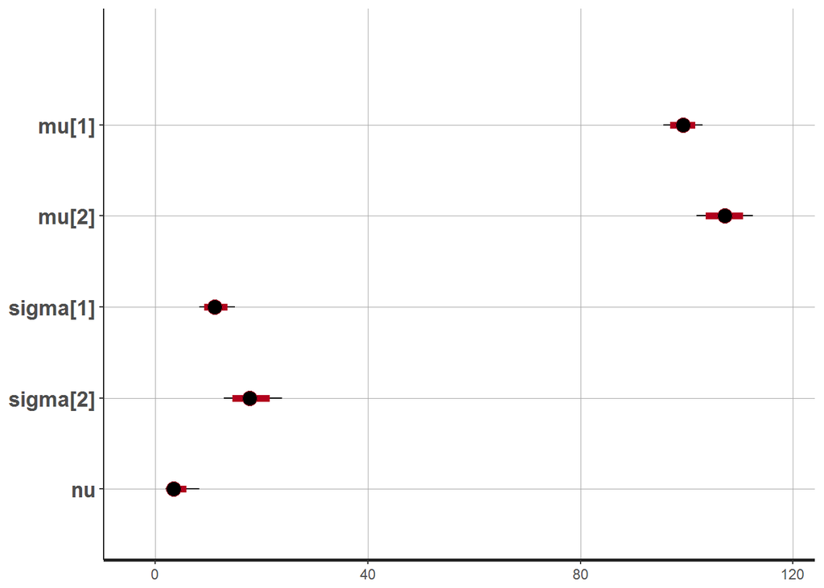

```r
plot(stanFitRobust)
```

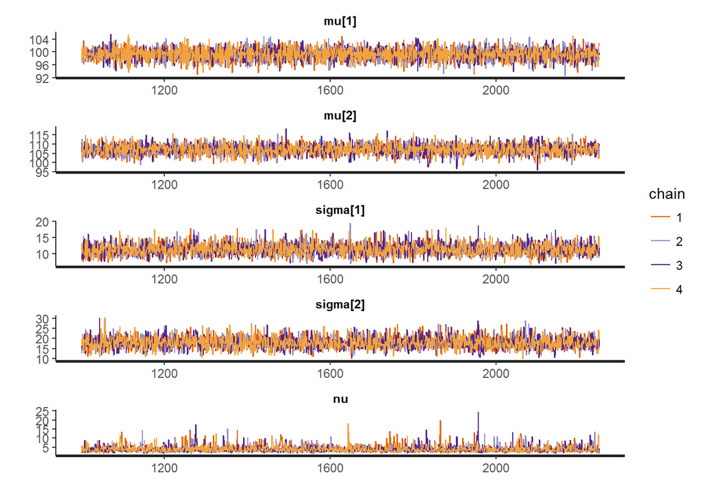

```r
rstan::traceplot(stanFitRobust, ncol=1, inc_warmup=F)
```

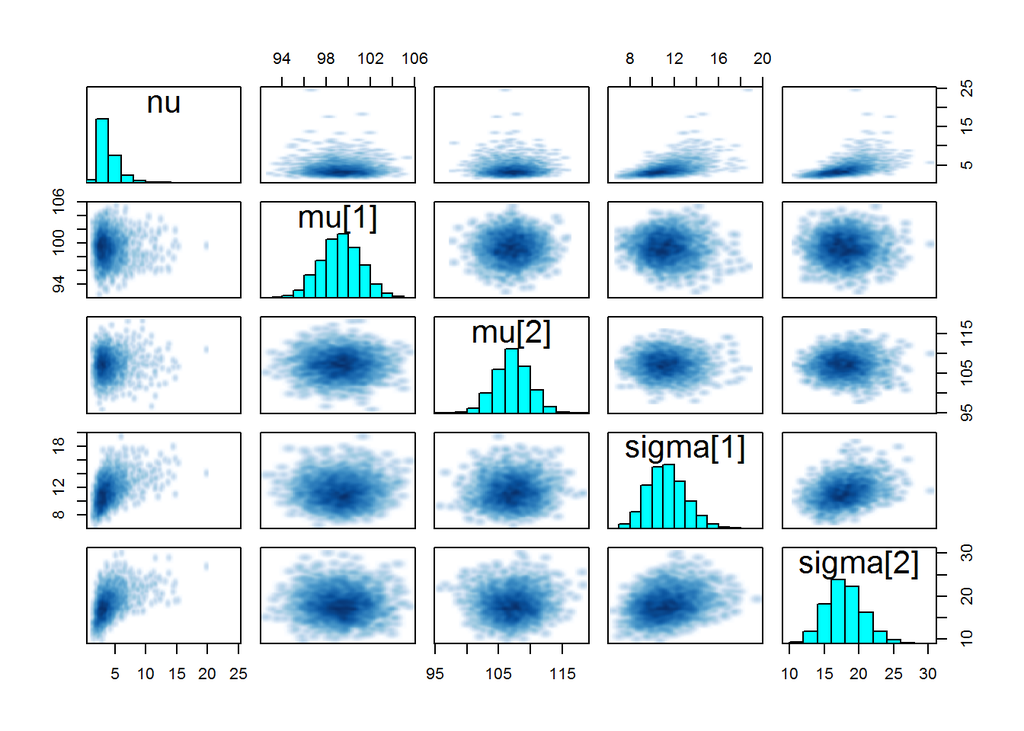

```r
pairs(stanFitRobust, pars=c('nu','mu','sigma'))
```

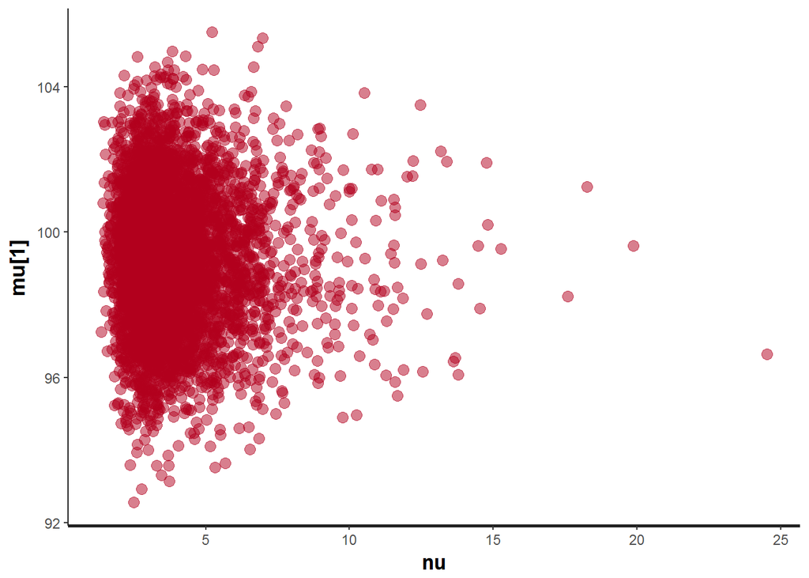

```r
stan_scat(stanFitRobust, c('nu','mu[1]'))
```

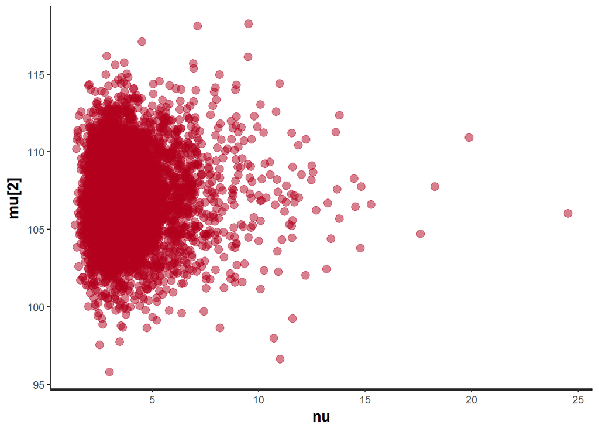

```r
stan_scat(stanFitRobust, c('nu','mu[2]'))
```

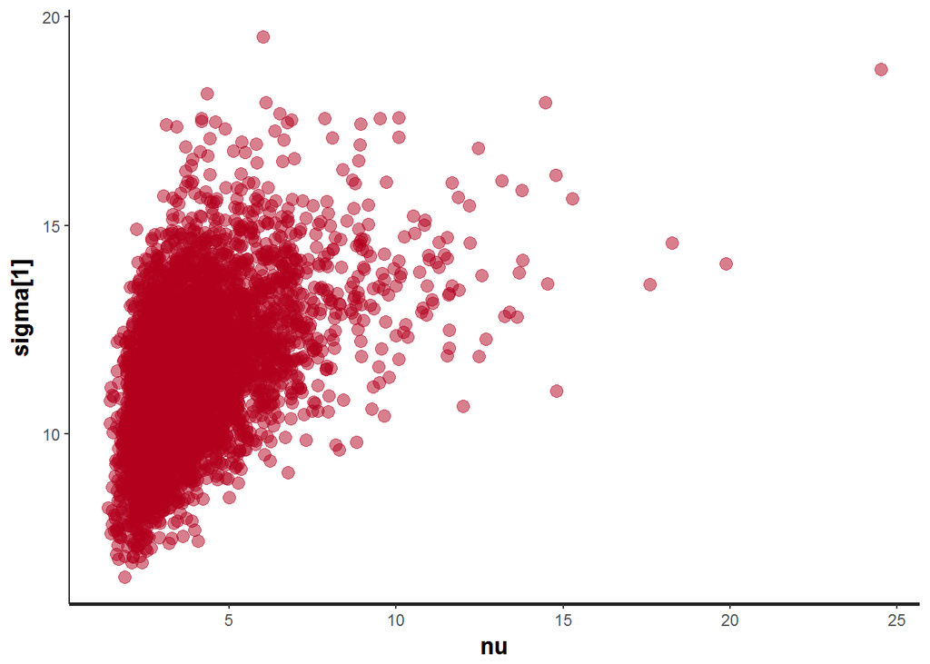

```r
stan_scat(stanFitRobust, c('nu','sigma[1]'))
```